# Tugas Praktikum MPDW M2

Qaulan Sadiida Putri Sumarna

2025-08-30

# Library

```r
library("forecast")
```

```r
library("graphics")
library("TTR")
library("TSA")
library(rio)
library(tseries)
library(ggplot2)
```

# Import Data

```r
data_minyak <- import("https://raw.githubusercontent.com/Sadiida/mpdw/main/Pertemuan%202/Data/crude-oil-price.csv")
head(data_minyak)
```

```
##         date price percentChange change
## 1 1983-03-01 29.27            NA     NA
## 2 1983-04-01 30.63         4.646   1.36
## 3 1983-05-01 30.25        -1.241  -0.38
## 4 1983-06-01 31.38         3.736   1.13
## 5 1983-07-01 32.00         1.976   0.62
## 6 1983-08-01 31.59        -1.281  -0.41
```

```r
dt <- data_minyak[128:254, c(1, 2) ]
head(dt)
```

```
##           date price
## 128 1993-10-01 16.92
## 129 1993-11-01 15.43
## 130 1993-12-01 14.17
## 131 1994-01-01 15.19
## 132 1994-02-01 14.48
## 133 1994-03-01 14.79
```

# Eksplorasi dan Visualisasi Data

## Plot pola musiman

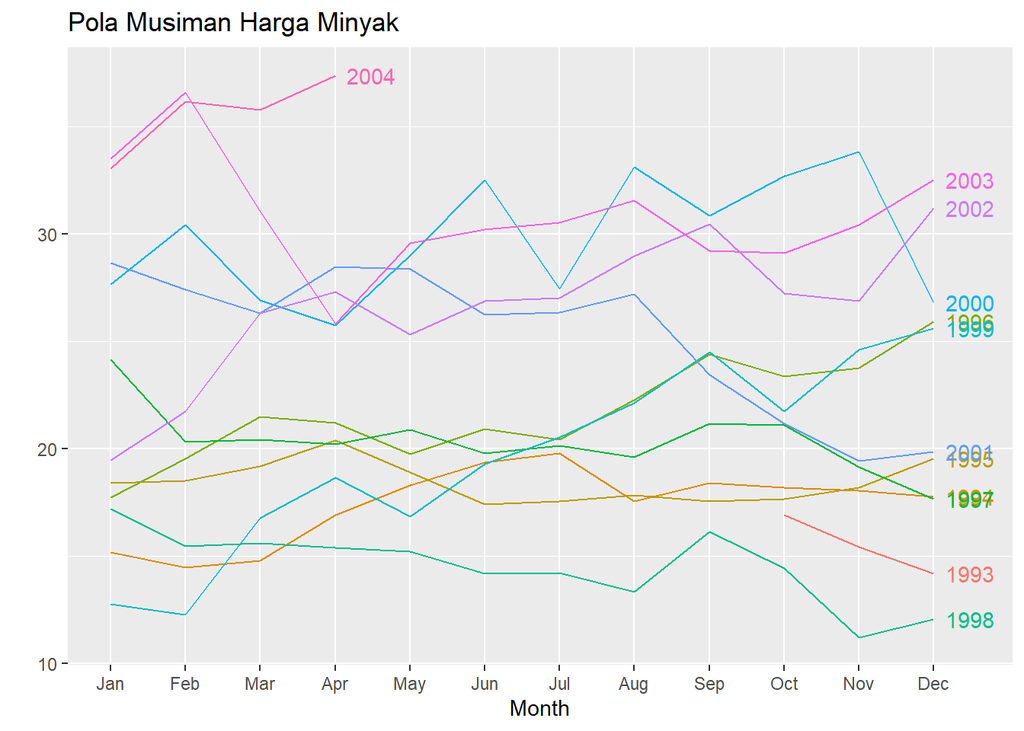

```r
# Ubah data jadi time series bulanan
ts_minyak <- ts(dt$price, start = c(1993, 10), frequency = 12)

# Plot pola musiman
ggseasonplot(ts_minyak, year.labels = TRUE, main = "Pola Musiman Harga Minyak")
```

Berdasarkan plot didapatkan bahwa: 1. Pola antar bulan tidak konsisten 2. Fluktuasi antar tahun sangat berbeda 3. Tidak ada musiman yang kuat Sehingga, data harga minyak bulanan dari 1993–2004 tidak menunjukkan pola musiman yang konsisten. Artinya, metode pemulusan yang mengandalkan musiman seperti Holt-Winters musiman mungkin kurang cocok.

## Dekomposisi

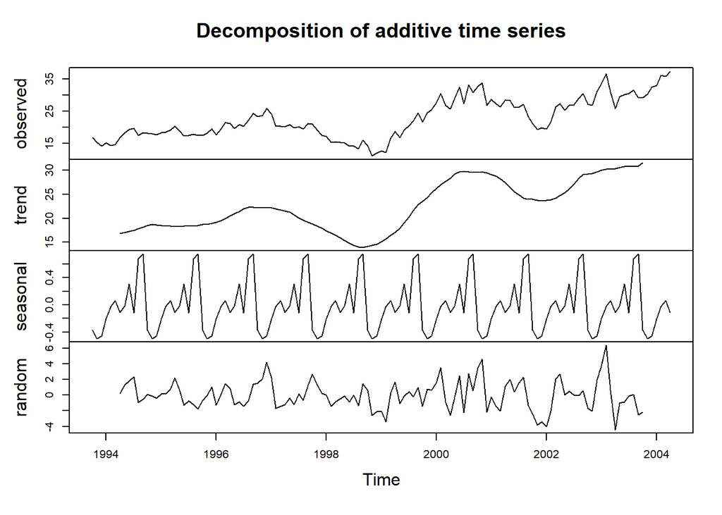

```r
dekomposisi <- decompose(ts_minyak)
plot(dekomposisi)
```

## ACF

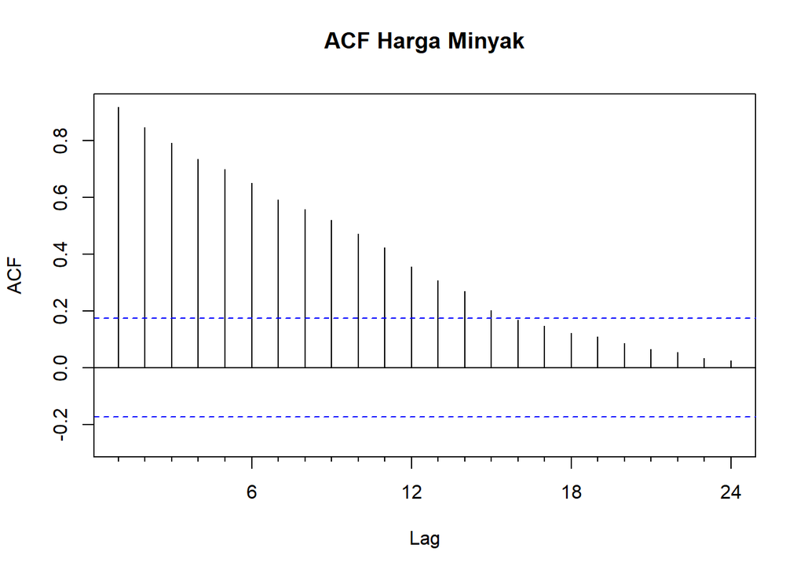

```r
Acf(ts_minyak, main = "ACF Harga Minyak")
```

Data harga minyak bulanan menunjukkan autokorelasi jangka pendek yang signifikan, tapi tidak menunjukkan pola musiman tahunan yang kuat. Ini mendukung hasil dari plot musiman dan dekomposisi sebelumnya, sehingga metode pemulusan non-musiman lebih cocok untuk analisis dan peramalan.

```r
View(dt)
str(dt)
```

```
## 'data.frame':    127 obs. of  2 variables:
##  $ date : POSIXct, format: "1993-10-01" "1993-11-01" ...
##  $ price: num  16.9 15.4 14.2 15.2 14.5 ...
```

```r
dim(dt)
```

```
## [1] 127   2
```

## Summary

```r
summary(ts_minyak)
```

```
##    Min. 1st Qu.  Median    Mean 3rd Qu.    Max.
##   11.22   17.95   21.08   22.70   27.25   37.38
```

## Plot

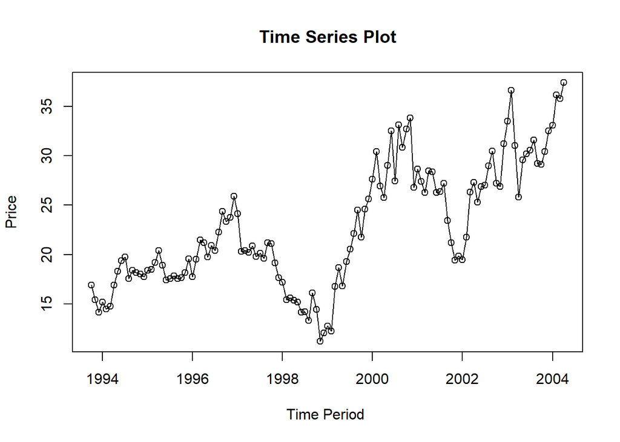

```r
ts.plot(ts_minyak, xlab="Time Period ", ylab="Price",
        main = "Time Series Plot")
points(ts_minyak)
```

Berdasarkan plot didapat: 1. Terdapat pola tren jangka panjang 2. Fluktuasi yang cukup tajam -> data volatile -> metode yang terlalu “halus” (seperti SMA) mungkin tidak cocok. 3. Tidak terlihat musiman yang konsisten 4. Data Cukup Stabil di Awal, Lebih Dinamis di Akhir

# Membagi data

```r
# Hitung jumlah data
n <- nrow(dt)

# Tentukan batas 80% untuk data latih
n_train <- floor(0.8 * n)

# Bagi data menjadi data latih dan data uji
training_ma <- dt[1:n_train, ]
testing_ma  <- dt[(n_train + 1):n, ]

train_ma.ts <- ts(training_ma$price, start = c(1993, 10), frequency = 12)

n_train <- nrow(training_ma)

# Hitung total bulan dari Oktober 1993 ke awal data uji
start_month_total <- (1993 - 1) * 12 + 10 + n_train  # total bulan sejak Januari tahun 1

# Konversi ke tahun dan bulan
start_year <- floor((start_month_total - 1) / 12)
start_month <- ((start_month_total - 1) %% 12) + 1

# Buat time series data uji dengan waktu yang sesuai
test_ma.ts <- ts(testing_ma$price, start = c(start_year, start_month), frequency = 12)
```

## Plot data

### data latih

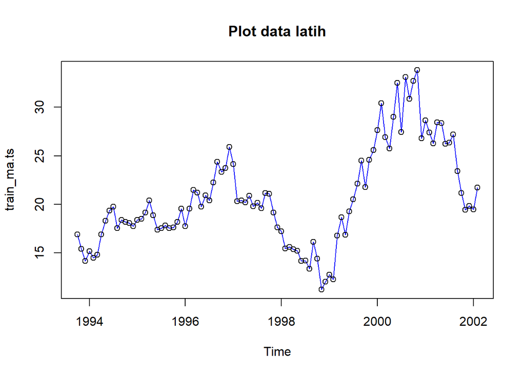

```r
plot(train_ma.ts, col="blue",main="Plot data latih")
points(train_ma.ts)
```

### data uji

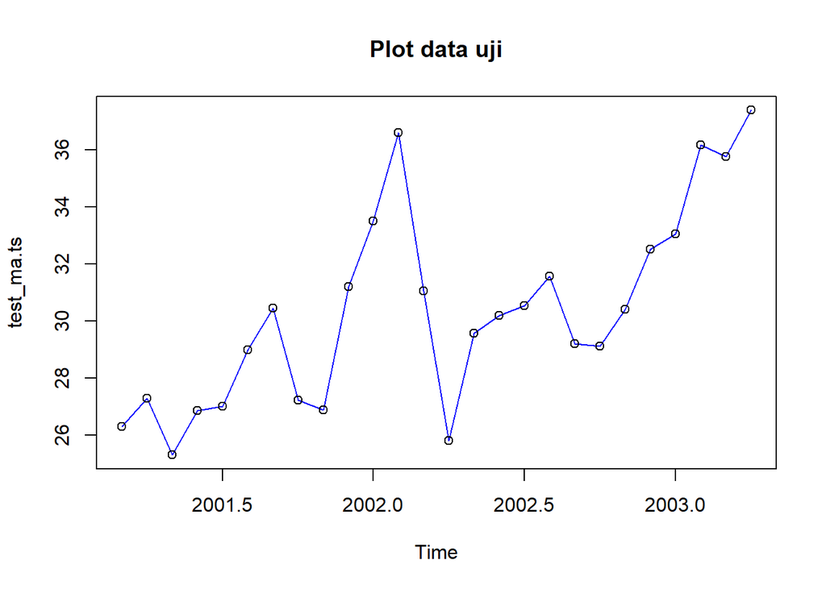

```r
#eksplorasi data uji
plot(test_ma.ts, col="blue",main="Plot data uji")
points(test_ma.ts)
```

### ggplot

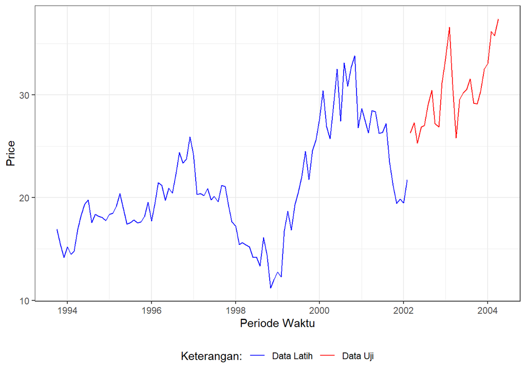

```r
ggplot() +
  geom_line(data = training_ma, aes(x = date, y = price, col = "Data Latih")) +
  geom_line(data = testing_ma, aes(x = date, y = price, col = "Data Uji")) +
  labs(x = "Periode Waktu", y = "Price", color = "Legend") +
   scale_colour_manual(name="Keterangan:", breaks = c("Data Latih", "Data Uji"),
                      values = c("blue", "red")) +
  theme_bw() + theme(legend.position = "bottom",
                     plot.caption = element_text(hjust=0.5, size=12))
```

# SMA (Single Moving Average)

```r
# Tentukan window (misalnya 3 bulan)
window_sma <- 3

# Hitung SMA pada data latih
sma_train <- SMA(training_ma$price, n = window_sma)

# Buat prediksi untuk data uji
# Prediksi SMA biasanya menggunakan nilai terakhir dari SMA latih
# atau kamu bisa hitung SMA pada gabungan data latih + uji

gabungan <- c(training_ma$price, testing_ma$price)
sma_full <- SMA(gabungan, n = window_sma)

# Ambil bagian prediksi untuk data uji
start_prediksi <- length(training_ma$price) + 1
end_prediksi <- length(gabungan)
prediksi_sma <- sma_full[start_prediksi:end_prediksi]

# Hitung akurasi terhadap data uji
actual <- testing_ma$price
MAPE_sma <- mean(abs((actual - prediksi_sma) / actual)) * 100
MSE_sma  <- mean((actual - prediksi_sma)^2)
RMSE_sma <- sqrt(MSE_sma)
SSE_sma  <- sum((actual - prediksi_sma)^2)

# Tampilkan hasil
cat("MAPE:", MAPE_sma, "\nMSE:", MSE_sma, "\nRMSE:", RMSE_sma, "\nSSE:", SSE_sma)
```

```
## MAPE: 5.678038
## MSE: 4.159226
## RMSE: 2.039418
## SSE: 108.1399
```

# DMA (Double Moving Average)

```r
# Tentukan window (misalnya 3 bulan)
window_dma <- 3

# Gabungkan data latih dan uji untuk prediksi penuh
gabungan <- c(training_ma$price, testing_ma$price)

# Langkah 1: SMA pertama
sma1 <- SMA(gabungan, n = window_dma)

# Langkah 2: SMA dari SMA pertama
sma2 <- SMA(sma1, n = window_dma)

# Hitung prediksi DMA (rumus: 2*SMA1 - SMA2)
dma_prediksi <- 2 * sma1 - sma2

# Ambil bagian prediksi untuk data uji
start_prediksi <- length(training_ma$price) + 1
end_prediksi <- length(gabungan)
prediksi_dma <- dma_prediksi[start_prediksi:end_prediksi]

# Hitung akurasi terhadap data uji
actual <- testing_ma$price
MAPE_dma <- mean(abs((actual - prediksi_dma) / actual)) * 100
MSE_dma  <- mean((actual - prediksi_dma)^2)
RMSE_dma <- sqrt(MSE_dma)
SSE_dma  <- sum((actual - prediksi_dma)^2)

# Tampilkan hasil
cat("MAPE:", MAPE_dma, "\nMSE:", MSE_dma, "\nRMSE:", RMSE_dma, "\nSSE:", SSE_dma)
```

```
## MAPE: 4.473534
## MSE: 2.993066
## RMSE: 1.730048
## SSE: 77.8197
```

Berdasarkan metode Moving Average, didapat nilai MAPE yang lebih baik untuk DMA dibanding SMA hal ini selaras dengan teori bahwa DMA lebih cocok untuk data yang memiliki pola tren.

# SES (Single Exponential Smoothing)

```r
library(forecast)

# SES alpha = 0.2
model_ses_02 <- ses(train_ma.ts, h = length(test_ma.ts), alpha = 0.2)
forecast_ses_02 <- forecast(model_ses_02)
prediksi_ses_02 <- window(forecast_ses_02$mean, start = start(test_ma.ts), end = end(test_ma.ts))
# SES alpha = 0.7
model_ses_07 <- ses(train_ma.ts, h = length(test_ma.ts), alpha = 0.7)
forecast_ses_07 <- forecast(model_ses_07)
prediksi_ses_07 <- window(forecast_ses_07$mean, start = start(test_ma.ts), end = end(test_ma.ts))
# SES alpha optimal
model_ses_opt <- ses(train_ma.ts, h = length(test_ma.ts))
forecast_ses_opt <- forecast(model_ses_opt)
prediksi_ses_opt <- window(forecast_ses_opt$mean, start = start(test_ma.ts), end = end(test_ma.ts))
```

```r
# Data aktual
actual <- test_ma.ts

# Hitung akurasi manual
mape <- function(actual, pred) mean(abs((actual - pred) / actual)) * 100
mse  <- function(actual, pred) mean((actual - pred)^2)
rmse <- function(actual, pred) sqrt(mse(actual, pred))
sse  <- function(actual, pred) sum((actual - pred)^2)

# Tampilkan hasil
cat("SES alpha = 0.2\n")
```

```
## SES alpha = 0.2
```

```r
cat("MAPE:", mape(actual, prediksi_ses_02), "\nMSE:", mse(actual, prediksi_ses_02),
    "\nRMSE:", rmse(actual, prediksi_ses_02), "\nSSE:", sse(actual, prediksi_ses_02), "\n\n")
```

```
## MAPE: 28.11984
## MSE: 91.84564
## RMSE: 9.583613
## SSE: 1285.839
```

```r
cat("SES alpha = 0.7\n")
```

```
## SES alpha = 0.7
```

```r
cat("MAPE:", mape(actual, prediksi_ses_07), "\nMSE:", mse(actual, prediksi_ses_07),
    "\nRMSE:", rmse(actual, prediksi_ses_07), "\nSSE:", sse(actual, prediksi_ses_07), "\n\n")
```

```
## MAPE: 32.58058
## MSE: 119.1828
## RMSE: 10.91709
## SSE: 1668.56
```

```r
cat("SES alpha = optimal\n")
```

```
## SES alpha = optimal
```

```r
cat("MAPE:", mape(actual, prediksi_ses_opt), "\nMSE:", mse(actual, prediksi_ses_opt),
    "\nRMSE:", rmse(actual, prediksi_ses_opt), "\nSSE:", sse(actual, prediksi_ses_opt), "\n")
```

```
## MAPE: 32.01294
## MSE: 115.4875
## RMSE: 10.74651
## SSE: 1616.825
```

#DES (Double Exponential Smoothing)

```r
# DES dengan alpha dan beta default (dipilih otomatis oleh R)
model_des_opt <- holt(train_ma.ts, h = length(test_ma.ts))
forecast_des_opt <- forecast(model_des_opt)
prediksi_des_opt <- window(forecast_des_opt$mean, start = start(test_ma.ts), end = end(test_ma.ts))
# Kasus 1: alpha = 0.2, beta = 0.2
model_des_1 <- holt(train_ma.ts, h = length(test_ma.ts), alpha = 0.2, beta = 0.2)
forecast_des_1 <- forecast(model_des_1)
prediksi_des_1 <- window(forecast_des_1$mean, start = start(test_ma.ts), end = end(test_ma.ts))
# Kasus 2: alpha = 0.6, beta = 0.3
model_des_2 <- holt(train_ma.ts, h = length(test_ma.ts), alpha = 0.6, beta = 0.3)
forecast_des_2 <- forecast(model_des_2)
prediksi_des_2 <- window(forecast_des_2$mean, start = start(test_ma.ts), end = end(test_ma.ts))
```

```r
# Data aktual
actual <- test_ma.ts

# Fungsi akurasi manual
mape <- function(actual, pred) mean(abs((actual - pred) / actual)) * 100
mse  <- function(actual, pred) mean((actual - pred)^2)
rmse <- function(actual, pred) sqrt(mse(actual, pred))
sse  <- function(actual, pred) sum((actual - pred)^2)

# Tampilkan hasil
cat("DES (Holt) - alpha & beta optimal\n")
```

```
## DES (Holt) - alpha & beta optimal
```

```r
cat("MAPE:", mape(actual, prediksi_des_opt), "\nMSE:", mse(actual, prediksi_des_opt),
    "\nRMSE:", rmse(actual, prediksi_des_opt), "\nSSE:", sse(actual, prediksi_des_opt), "\n\n")
```

```
## MAPE: 30.42818
## MSE: 104.4125
## RMSE: 10.21824
## SSE: 1461.775
```

```r
cat("DES - alpha = 0.2, beta = 0.2\n")
```

```
## DES - alpha = 0.2, beta = 0.2
```

```r
cat("MAPE:", mape(actual, prediksi_des_1), "\nMSE:", mse(actual, prediksi_des_1),
    "\nRMSE:", rmse(actual, prediksi_des_1), "\nSSE:", sse(actual, prediksi_des_1), "\n\n")
```

```
## MAPE: 62.36773
## MSE: 442.7033
## RMSE: 21.04052
## SSE: 6197.846
```

```r
cat("DES - alpha = 0.6, beta = 0.3\n")
```

```
## DES - alpha = 0.6, beta = 0.3
```

```r
cat("MAPE:", mape(actual, prediksi_des_2), "\nMSE:", mse(actual, prediksi_des_2),
    "\nRMSE:", rmse(actual, prediksi_des_2), "\nSSE:", sse(actual, prediksi_des_2), "\n")
```

```
## MAPE: 28.67234
## MSE: 88.86792
## RMSE: 9.426978
## SSE: 1244.151
```

# Visualisasi hasil aktual dan prediksi dengan metode terbaik

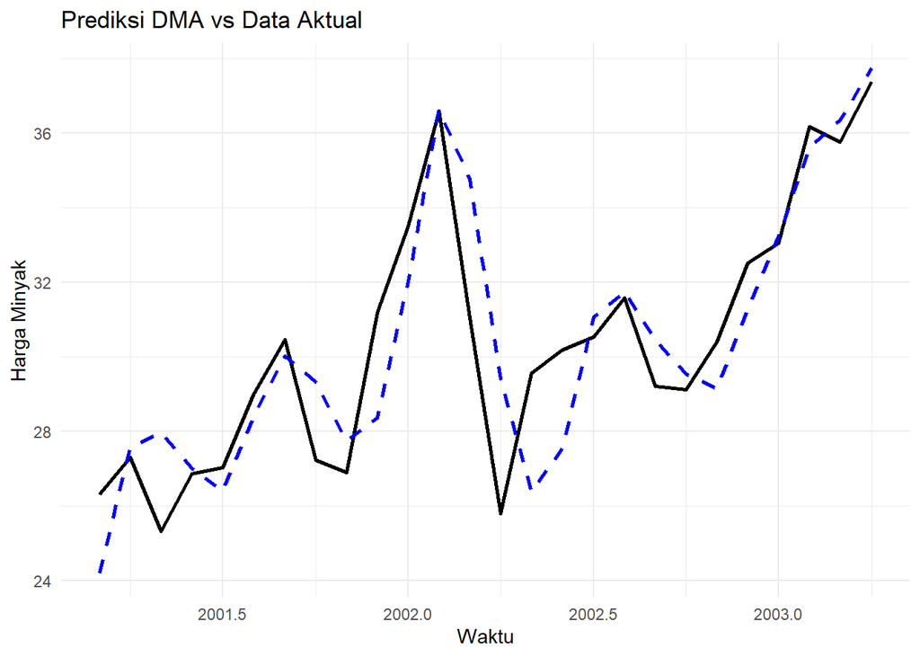

```r
# Gabungkan data aktual dan prediksi DMA
n_train <- nrow(training_ma)
gabungan <- c(training_ma$price, testing_ma$price)
sma1 <- SMA(gabungan, n = 3)
sma2 <- SMA(sma1, n = 3)
dma <- 2 * sma1 - sma2

# Ambil prediksi DMA untuk data uji
start_prediksi <- n_train + 1
end_prediksi <- length(gabungan)
prediksi_dma <- dma[start_prediksi:end_prediksi]

# Buat data frame untuk plotting
df_plot <- data.frame(
  Time = time(test_ma.ts),
  Actual = testing_ma$price,
  Prediksi_DMA = prediksi_dma
)

# Plot
ggplot(df_plot, aes(x = Time)) +
  geom_line(aes(y = Actual), color = "black", size = 1, linetype = "solid") +
  geom_line(aes(y = Prediksi_DMA), color = "blue", size = 1, linetype = "dashed") +
  labs(title = "Prediksi DMA vs Data Aktual",
       y = "Harga Minyak",
       x = "Waktu") +
  theme_minimal()
```

DMA memberikan prediksi yang stabil dan cukup akurat secara tren, meskipun tidak menangkap fluktuasi ekstrem. Ini cocok untuk data seperti harga minyak yang punya tren ringan dan noise moderat.

# Kesimpulan

Berdasarkan eksplorasi dan evaluasi berbagai metode pemulusan terhadap data harga minyak bulanan, ditemukan bahwa Double Moving Average (DMA) memberikan performa terbaik dengan nilai MAPE paling rendah. Meskipun metode seperti Simple Exponential Smoothing (SES) dan Double Exponential Smoothing (DES) menawarkan pendekatan yang lebih kompleks, hasil empiris menunjukkan bahwa stabilitas dan kesederhanaan DMA justru lebih efektif dalam menangkap tren ringan dan fluktuasi moderat pada data.

Visualisasi prediksi DMA terhadap data aktual memperkuat temuan ini: garis prediksi mengikuti arah umum tren dengan cukup baik, meskipun ada sedikit keterlambatan dalam merespons lonjakan tajam. Kesimpulannya, untuk data deret waktu yang tidak menunjukkan pola musiman dan memiliki tren bertahap, DMA merupakan pilihan yang paling akurat dan stabil di antara metode yang telah diuji.

# Tugas Praktikum MPDW M2

Qaulan Sadiida Putri Sumarna

2025-08-30

# Library

```r
library("forecast")
```

```r
library("graphics")
library("TTR")
library("TSA")
library(rio)
library(tseries)
library(ggplot2)
```

# Import Data

```r
data_minyak <- import("https://raw.githubusercontent.com/Sadiida/mpdw/main/Pertemuan%202/Data/crude-oil-price.csv")
head(data_minyak)
```

```
##         date price percentChange change
## 1 1983-03-01 29.27            NA     NA
## 2 1983-04-01 30.63         4.646   1.36
## 3 1983-05-01 30.25        -1.241  -0.38
## 4 1983-06-01 31.38         3.736   1.13
## 5 1983-07-01 32.00         1.976   0.62
## 6 1983-08-01 31.59        -1.281  -0.41
```

```r
dt <- data_minyak[128:254, c(1, 2) ]
head(dt)
```

```
##           date price
## 128 1993-10-01 16.92
## 129 1993-11-01 15.43
## 130 1993-12-01 14.17
## 131 1994-01-01 15.19
## 132 1994-02-01 14.48
## 133 1994-03-01 14.79
```

# Eksplorasi dan Visualisasi Data

## Plot pola musiman

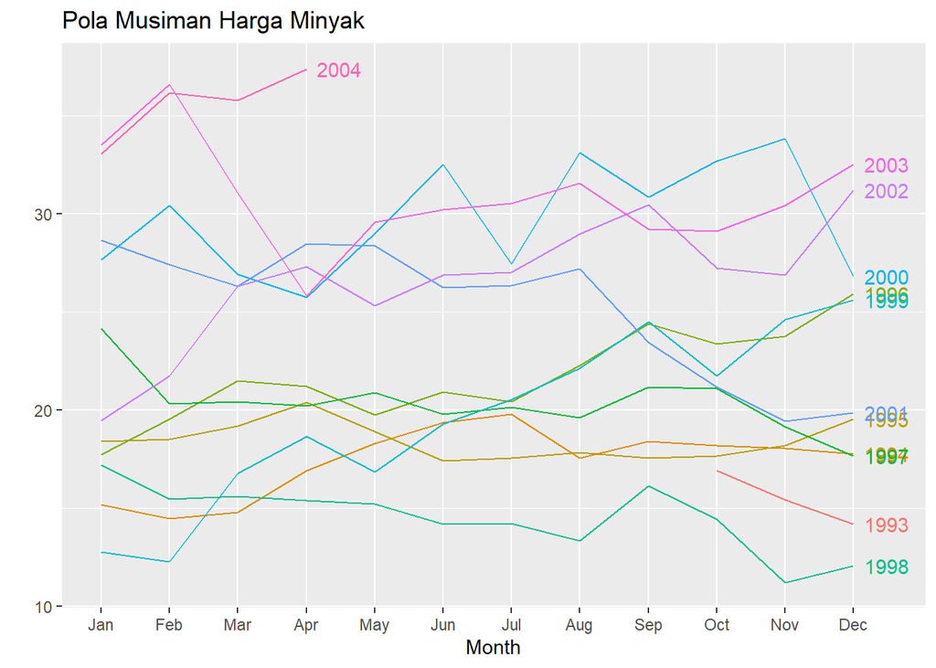

```r
# Ubah data jadi time series bulanan
ts_minyak <- ts(dt$price, start = c(1993, 10), frequency = 12)

# Plot pola musiman
ggseasonplot(ts_minyak, year.labels = TRUE, main = "Pola Musiman Harga Minyak")
```

Berdasarkan plot didapatkan bahwa: 1. Pola antar bulan tidak konsisten 2. Fluktuasi antar tahun sangat berbeda 3. Tidak ada musiman yang kuat Sehingga, data harga minyak bulanan dari 1993–2004 tidak menunjukkan pola musiman yang konsisten. Artinya, metode pemulusan yang mengandalkan musiman seperti Holt-Winters musiman mungkin kurang cocok.

## Dekomposisi

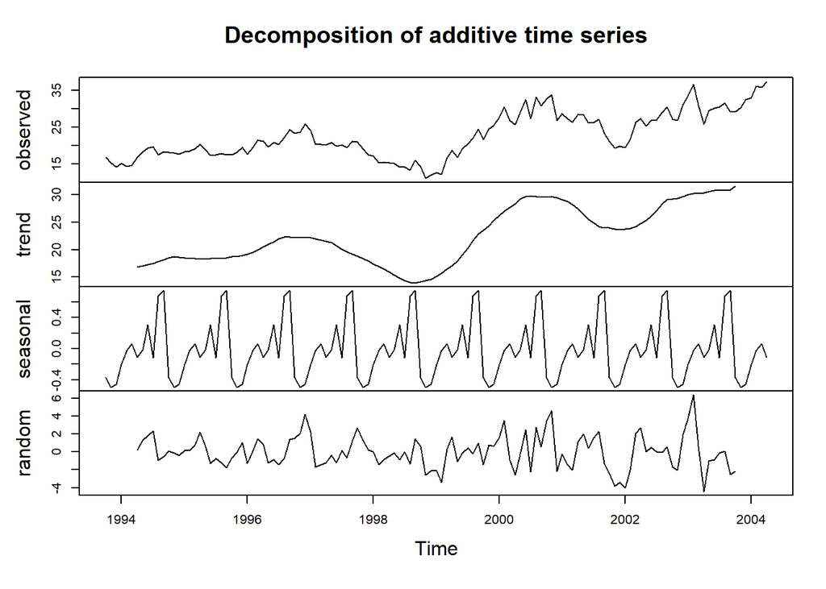

```r
dekomposisi <- decompose(ts_minyak)
plot(dekomposisi)
```

## ACF

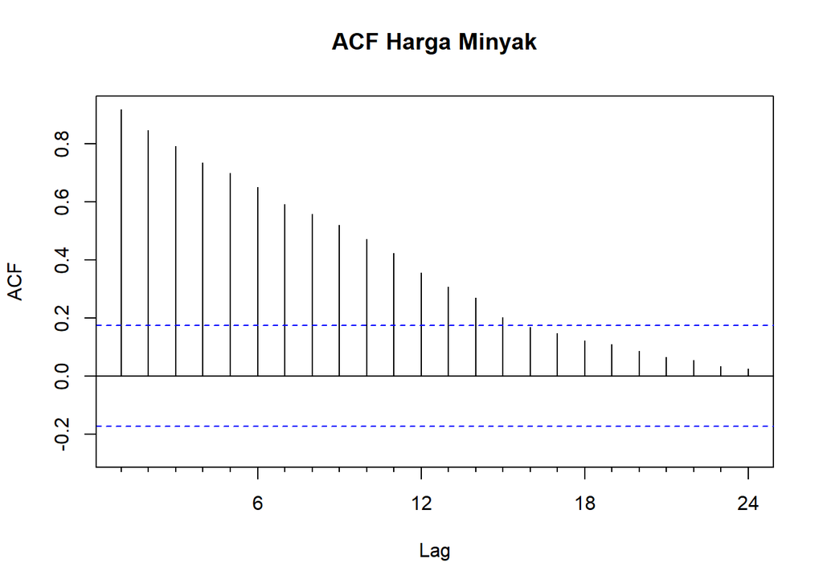

```r
Acf(ts_minyak, main = "ACF Harga Minyak")
```

Data harga minyak bulanan menunjukkan autokorelasi jangka pendek yang signifikan, tapi tidak menunjukkan pola musiman tahunan yang kuat. Ini mendukung hasil dari plot musiman dan dekomposisi sebelumnya, sehingga metode pemulusan non-musiman lebih cocok untuk analisis dan peramalan.

```r
View(dt)
str(dt)
```

```
## 'data.frame':    127 obs. of  2 variables:
##  $ date : POSIXct, format: "1993-10-01" "1993-11-01" ...
##  $ price: num  16.9 15.4 14.2 15.2 14.5 ...
```

```r
dim(dt)
```

```
## [1] 127   2
```

## Summary

```r
summary(ts_minyak)
```

```
##    Min. 1st Qu.  Median    Mean 3rd Qu.    Max.
##   11.22   17.95   21.08   22.70   27.25   37.38
```

## Plot

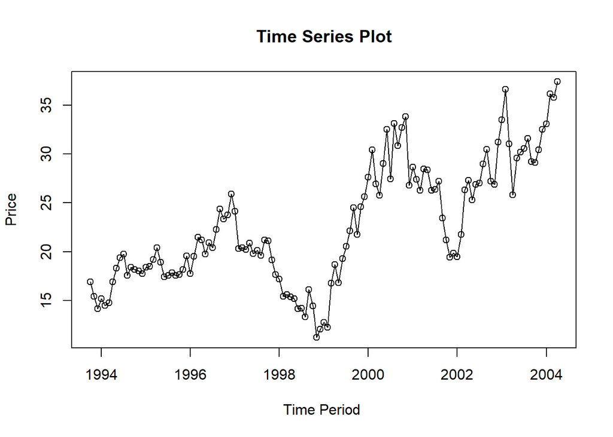

```r
ts.plot(ts_minyak, xlab="Time Period ", ylab="Price",
        main = "Time Series Plot")
points(ts_minyak)
```

Berdasarkan plot didapat: 1. Terdapat pola tren jangka panjang 2. Fluktuasi yang cukup tajam -> data volatile -> metode yang terlalu “halus” (seperti SMA) mungkin tidak cocok. 3. Tidak terlihat musiman yang konsisten 4. Data Cukup Stabil di Awal, Lebih Dinamis di Akhir

# Membagi data

```r
# Hitung jumlah data
n <- nrow(dt)

# Tentukan batas 80% untuk data latih
n_train <- floor(0.8 * n)

# Bagi data menjadi data latih dan data uji
training_ma <- dt[1:n_train, ]
testing_ma  <- dt[(n_train + 1):n, ]

train_ma.ts <- ts(training_ma$price, start = c(1993, 10), frequency = 12)

n_train <- nrow(training_ma)

# Hitung total bulan dari Oktober 1993 ke awal data uji
start_month_total <- (1993 - 1) * 12 + 10 + n_train  # total bulan sejak Januari tahun 1

# Konversi ke tahun dan bulan
start_year <- floor((start_month_total - 1) / 12)
start_month <- ((start_month_total - 1) %% 12) + 1

# Buat time series data uji dengan waktu yang sesuai
test_ma.ts <- ts(testing_ma$price, start = c(start_year, start_month), frequency = 12)
```

## Plot data

### data latih

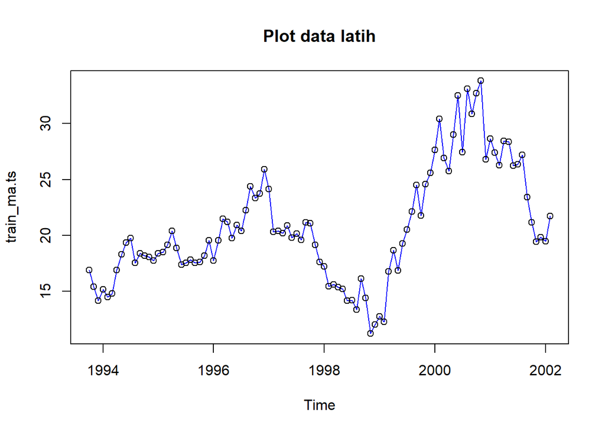

```r
plot(train_ma.ts, col="blue",main="Plot data latih")
points(train_ma.ts)
```

### data uji

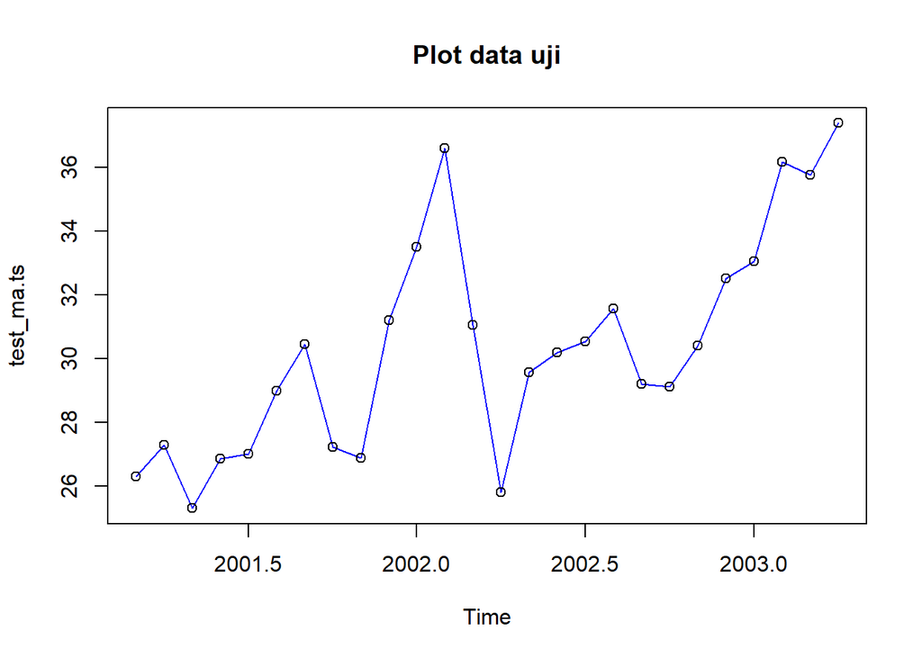

```r
#eksplorasi data uji
plot(test_ma.ts, col="blue",main="Plot data uji")
points(test_ma.ts)
```

### ggplot

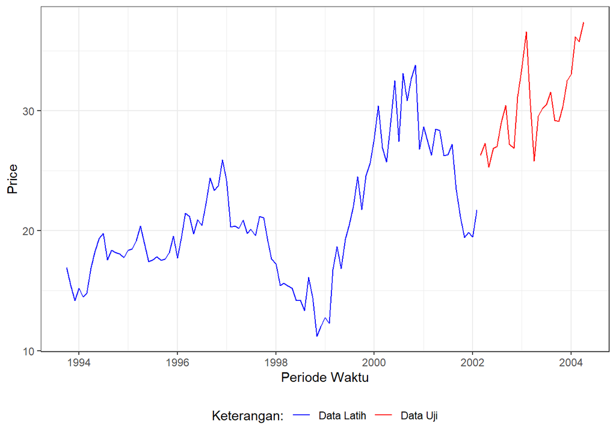

```r
ggplot() +
  geom_line(data = training_ma, aes(x = date, y = price, col = "Data Latih")) +
  geom_line(data = testing_ma, aes(x = date, y = price, col = "Data Uji")) +
  labs(x = "Periode Waktu", y = "Price", color = "Legend") +
   scale_colour_manual(name="Keterangan:", breaks = c("Data Latih", "Data Uji"),
                      values = c("blue", "red")) +
  theme_bw() + theme(legend.position = "bottom",
                     plot.caption = element_text(hjust=0.5, size=12))
```

# SMA (Single Moving Average)

```r
# Tentukan window (misalnya 3 bulan)
window_sma <- 3

# Hitung SMA pada data latih
sma_train <- SMA(training_ma$price, n = window_sma)

# Buat prediksi untuk data uji
# Prediksi SMA biasanya menggunakan nilai terakhir dari SMA latih
# atau kamu bisa hitung SMA pada gabungan data latih + uji

gabungan <- c(training_ma$price, testing_ma$price)
sma_full <- SMA(gabungan, n = window_sma)

# Ambil bagian prediksi untuk data uji
start_prediksi <- length(training_ma$price) + 1
end_prediksi <- length(gabungan)
prediksi_sma <- sma_full[start_prediksi:end_prediksi]

# Hitung akurasi terhadap data uji
actual <- testing_ma$price
MAPE_sma <- mean(abs((actual - prediksi_sma) / actual)) * 100
MSE_sma  <- mean((actual - prediksi_sma)^2)
RMSE_sma <- sqrt(MSE_sma)
SSE_sma  <- sum((actual - prediksi_sma)^2)

# Tampilkan hasil
cat("MAPE:", MAPE_sma, "\nMSE:", MSE_sma, "\nRMSE:", RMSE_sma, "\nSSE:", SSE_sma)
```

```
## MAPE: 5.678038
## MSE: 4.159226
## RMSE: 2.039418
## SSE: 108.1399
```

# DMA (Double Moving Average)

```r
# Tentukan window (misalnya 3 bulan)
window_dma <- 3

# Gabungkan data latih dan uji untuk prediksi penuh
gabungan <- c(training_ma$price, testing_ma$price)

# Langkah 1: SMA pertama
sma1 <- SMA(gabungan, n = window_dma)

# Langkah 2: SMA dari SMA pertama
sma2 <- SMA(sma1, n = window_dma)

# Hitung prediksi DMA (rumus: 2*SMA1 - SMA2)
dma_prediksi <- 2 * sma1 - sma2

# Ambil bagian prediksi untuk data uji
start_prediksi <- length(training_ma$price) + 1
end_prediksi <- length(gabungan)
prediksi_dma <- dma_prediksi[start_prediksi:end_prediksi]

# Hitung akurasi terhadap data uji
actual <- testing_ma$price
MAPE_dma <- mean(abs((actual - prediksi_dma) / actual)) * 100
MSE_dma  <- mean((actual - prediksi_dma)^2)
RMSE_dma <- sqrt(MSE_dma)
SSE_dma  <- sum((actual - prediksi_dma)^2)

# Tampilkan hasil
cat("MAPE:", MAPE_dma, "\nMSE:", MSE_dma, "\nRMSE:", RMSE_dma, "\nSSE:", SSE_dma)
```

```
## MAPE: 4.473534
## MSE: 2.993066
## RMSE: 1.730048
## SSE: 77.8197
```

Berdasarkan metode Moving Average, didapat nilai MAPE yang lebih baik untuk DMA dibanding SMA hal ini selaras dengan teori bahwa DMA lebih cocok untuk data yang memiliki pola tren.

# SES (Single Exponential Smoothing)

```r
library(forecast)

# SES alpha = 0.2
model_ses_02 <- ses(train_ma.ts, h = length(test_ma.ts), alpha = 0.2)
forecast_ses_02 <- forecast(model_ses_02)
prediksi_ses_02 <- window(forecast_ses_02$mean, start = start(test_ma.ts), end = end(test_ma.ts))
# SES alpha = 0.7
model_ses_07 <- ses(train_ma.ts, h = length(test_ma.ts), alpha = 0.7)
forecast_ses_07 <- forecast(model_ses_07)
prediksi_ses_07 <- window(forecast_ses_07$mean, start = start(test_ma.ts), end = end(test_ma.ts))
# SES alpha optimal
model_ses_opt <- ses(train_ma.ts, h = length(test_ma.ts))
forecast_ses_opt <- forecast(model_ses_opt)
prediksi_ses_opt <- window(forecast_ses_opt$mean, start = start(test_ma.ts), end = end(test_ma.ts))
```

```r
# Data aktual
actual <- test_ma.ts

# Hitung akurasi manual
mape <- function(actual, pred) mean(abs((actual - pred) / actual)) * 100
mse  <- function(actual, pred) mean((actual - pred)^2)
rmse <- function(actual, pred) sqrt(mse(actual, pred))
sse  <- function(actual, pred) sum((actual - pred)^2)

# Tampilkan hasil
cat("SES alpha = 0.2\n")
```

```
## SES alpha = 0.2
```

```r
cat("MAPE:", mape(actual, prediksi_ses_02), "\nMSE:", mse(actual, prediksi_ses_02),
    "\nRMSE:", rmse(actual, prediksi_ses_02), "\nSSE:", sse(actual, prediksi_ses_02), "\n\n")
```

```
## MAPE: 28.11984
## MSE: 91.84564
## RMSE: 9.583613
## SSE: 1285.839
```

```r
cat("SES alpha = 0.7\n")
```

```
## SES alpha = 0.7
```

```r
cat("MAPE:", mape(actual, prediksi_ses_07), "\nMSE:", mse(actual, prediksi_ses_07),
    "\nRMSE:", rmse(actual, prediksi_ses_07), "\nSSE:", sse(actual, prediksi_ses_07), "\n\n")
```

```
## MAPE: 32.58058
## MSE: 119.1828
## RMSE: 10.91709
## SSE: 1668.56
```

```r
cat("SES alpha = optimal\n")
```

```
## SES alpha = optimal
```

```r
cat("MAPE:", mape(actual, prediksi_ses_opt), "\nMSE:", mse(actual, prediksi_ses_opt),
    "\nRMSE:", rmse(actual, prediksi_ses_opt), "\nSSE:", sse(actual, prediksi_ses_opt), "\n")
```

```
## MAPE: 32.01294
## MSE: 115.4875
## RMSE: 10.74651
## SSE: 1616.825
```

#DES (Double Exponential Smoothing)

```r
# DES dengan alpha dan beta default (dipilih otomatis oleh R)
model_des_opt <- holt(train_ma.ts, h = length(test_ma.ts))
forecast_des_opt <- forecast(model_des_opt)
prediksi_des_opt <- window(forecast_des_opt$mean, start = start(test_ma.ts), end = end(test_ma.ts))
# Kasus 1: alpha = 0.2, beta = 0.2
model_des_1 <- holt(train_ma.ts, h = length(test_ma.ts), alpha = 0.2, beta = 0.2)
forecast_des_1 <- forecast(model_des_1)
prediksi_des_1 <- window(forecast_des_1$mean, start = start(test_ma.ts), end = end(test_ma.ts))
# Kasus 2: alpha = 0.6, beta = 0.3
model_des_2 <- holt(train_ma.ts, h = length(test_ma.ts), alpha = 0.6, beta = 0.3)
forecast_des_2 <- forecast(model_des_2)
prediksi_des_2 <- window(forecast_des_2$mean, start = start(test_ma.ts), end = end(test_ma.ts))
```

```r
# Data aktual
actual <- test_ma.ts

# Fungsi akurasi manual
mape <- function(actual, pred) mean(abs((actual - pred) / actual)) * 100
mse  <- function(actual, pred) mean((actual - pred)^2)
rmse <- function(actual, pred) sqrt(mse(actual, pred))
sse  <- function(actual, pred) sum((actual - pred)^2)

# Tampilkan hasil
cat("DES (Holt) - alpha & beta optimal\n")
```

```
## DES (Holt) - alpha & beta optimal
```

```r
cat("MAPE:", mape(actual, prediksi_des_opt), "\nMSE:", mse(actual, prediksi_des_opt),
    "\nRMSE:", rmse(actual, prediksi_des_opt), "\nSSE:", sse(actual, prediksi_des_opt), "\n\n")
```

```
## MAPE: 30.42818
## MSE: 104.4125
## RMSE: 10.21824
## SSE: 1461.775
```

```r
cat("DES - alpha = 0.2, beta = 0.2\n")
```

```
## DES - alpha = 0.2, beta = 0.2
```

```r
cat("MAPE:", mape(actual, prediksi_des_1), "\nMSE:", mse(actual, prediksi_des_1),
    "\nRMSE:", rmse(actual, prediksi_des_1), "\nSSE:", sse(actual, prediksi_des_1), "\n\n")
```

```
## MAPE: 62.36773
## MSE: 442.7033
## RMSE: 21.04052
## SSE: 6197.846
```

```r
cat("DES - alpha = 0.6, beta = 0.3\n")
```

```
## DES - alpha = 0.6, beta = 0.3
```

```r
cat("MAPE:", mape(actual, prediksi_des_2), "\nMSE:", mse(actual, prediksi_des_2),
    "\nRMSE:", rmse(actual, prediksi_des_2), "\nSSE:", sse(actual, prediksi_des_2), "\n")
```

```
## MAPE: 28.67234
## MSE: 88.86792
## RMSE: 9.426978
## SSE: 1244.151
```

# Visualisasi hasil aktual dan prediksi dengan metode terbaik

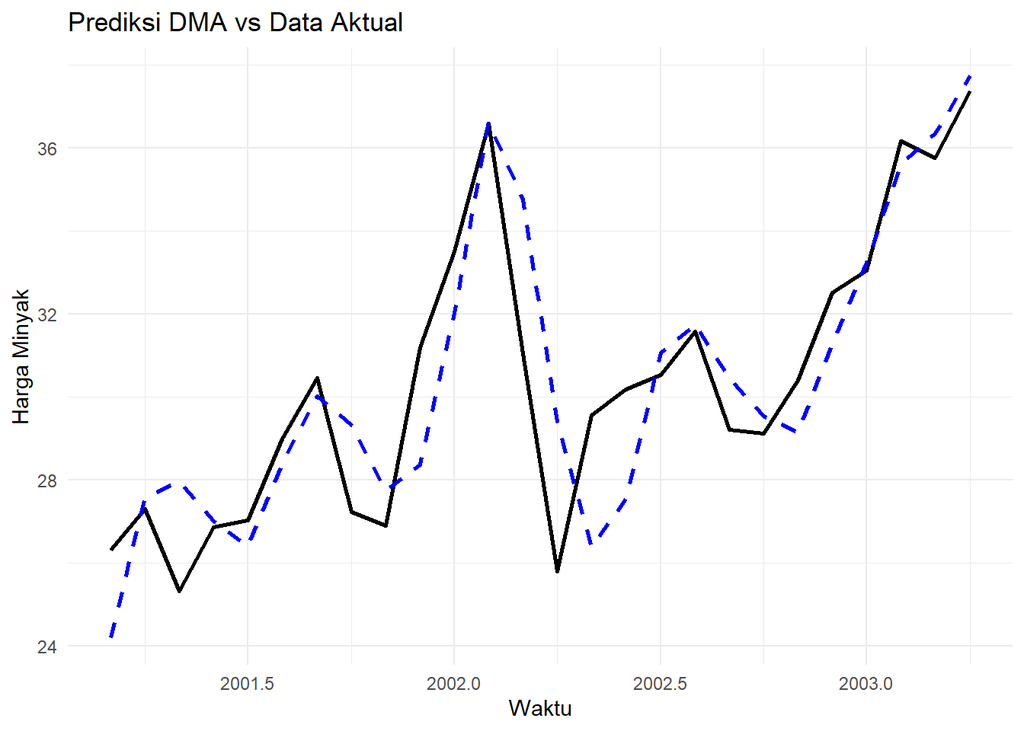

```r
# Gabungkan data aktual dan prediksi DMA
n_train <- nrow(training_ma)
gabungan <- c(training_ma$price, testing_ma$price)
sma1 <- SMA(gabungan, n = 3)
sma2 <- SMA(sma1, n = 3)
dma <- 2 * sma1 - sma2

# Ambil prediksi DMA untuk data uji
start_prediksi <- n_train + 1
end_prediksi <- length(gabungan)
prediksi_dma <- dma[start_prediksi:end_prediksi]

# Buat data frame untuk plotting
df_plot <- data.frame(
  Time = time(test_ma.ts),
  Actual = testing_ma$price,
  Prediksi_DMA = prediksi_dma
)

# Plot
ggplot(df_plot, aes(x = Time)) +
  geom_line(aes(y = Actual), color = "black", size = 1, linetype = "solid") +
  geom_line(aes(y = Prediksi_DMA), color = "blue", size = 1, linetype = "dashed") +
  labs(title = "Prediksi DMA vs Data Aktual",
       y = "Harga Minyak",
       x = "Waktu") +
  theme_minimal()
```

DMA memberikan prediksi yang stabil dan cukup akurat secara tren, meskipun tidak menangkap fluktuasi ekstrem. Ini cocok untuk data seperti harga minyak yang punya tren ringan dan noise moderat.

# Kesimpulan

Berdasarkan eksplorasi dan evaluasi berbagai metode pemulusan terhadap data harga minyak bulanan, ditemukan bahwa Double Moving Average (DMA) memberikan performa terbaik dengan nilai MAPE paling rendah. Meskipun metode seperti Simple Exponential Smoothing (SES) dan Double Exponential Smoothing (DES) menawarkan pendekatan yang lebih kompleks, hasil empiris menunjukkan bahwa stabilitas dan kesederhanaan DMA justru lebih efektif dalam menangkap tren ringan dan fluktuasi moderat pada data.

Visualisasi prediksi DMA terhadap data aktual memperkuat temuan ini: garis prediksi mengikuti arah umum tren dengan cukup baik, meskipun ada sedikit keterlambatan dalam merespons lonjakan tajam. Kesimpulannya, untuk data deret waktu yang tidak menunjukkan pola musiman dan memiliki tren bertahap, DMA merupakan pilihan yang paling akurat dan stabil di antara metode yang telah diuji.